# Figures and analysis to accompany ‘Canine Sniffing Biomechanic Responses to Varied Physical Properties’

Lydia Burnett<sup>1</sup>, Lindsay Waldrop<sup>2</sup>, Nick Hebdon<sup>2</sup>, Pete Stevens<sup>3</sup>,

Monica Moljo<sup>1</sup>, Lauryn DeGreeff<sup>1</sup>

2024-05-30

# Instructions for running code

This code notebook contains all code needed to reproduce the figures and statistics of the manuscript. It was run with R version 4.4.0 (2024-04-24) and RStudio v 2024.04.1+748 (2024.04.1+748).

To rerun the code in this file:

1. Clone the Github project at https://github.com/lindsaywaldrop/dog-sniffs
2. Open RStudio and the RProject file dog-sniffs.Rproj.
3. Open the Reproduction.Rmd and click Run and Run all.

Most code is not echoed in the HTML notebook file, but it is present in the RMD file.

Note: the terminology in the code often refers to sport dogs as “civilian” and law-enforcement dogs as “operational”.

# Reproduction of full analysis

Coming Soon!

# Reproduction of data-driven figures in manuscript

This RMD will call a csv file in the results directory produced from a previous run of the full analysis code from raw sensor data with the date:

```r
analysis_date <- "2023-08-30"
```

If you would like to rerun the full analysis, please change the above date to the date which you ran the full analysis code.

Loads required libraries:

```r
library(knitr)
library(ggrepel)
library(here)
library(ggplot2)
library(viridis)
library(patchwork)
library(forcats)
library(dplyr)
library(signal)
library(pracma)
```

Loading results and performing initial calculations:

```
You can override using the `.groups` argument.
'weight'. You can override using the `.groups` argument.
```

Setting color palettes and labels for figures:

## Figure 2

Code loads in raw sensor data (in the data/flowsensor directory), filters, and clips to a snapshot to produce figure 2.

```
[1] "Rezeroing by: -0.0195223139344275"
```

Figure 2 reproduction:

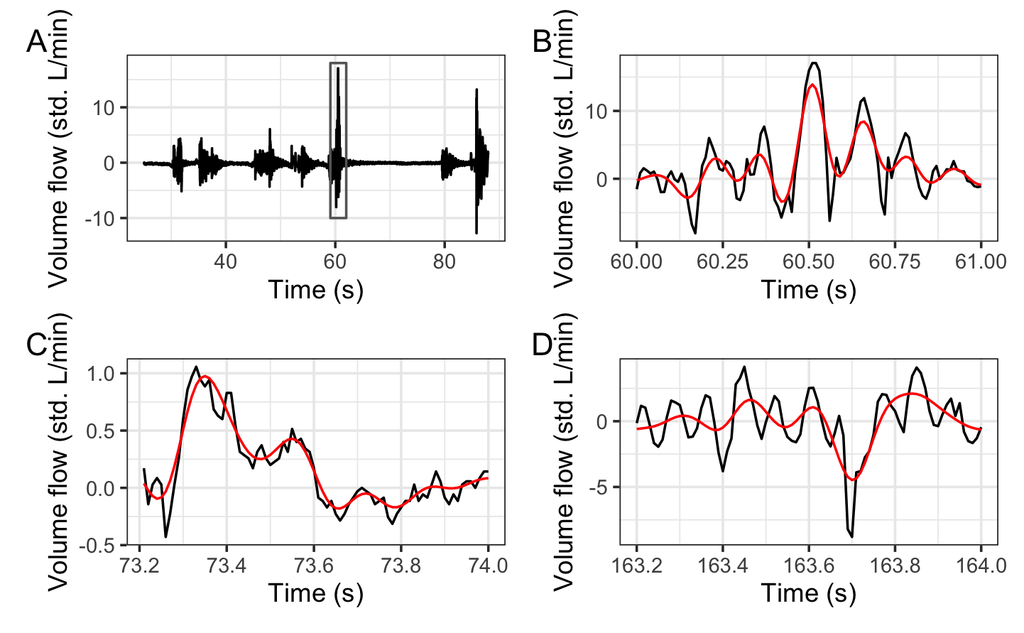

## Figure 3

[figure not shown]

Accompanying statistical comparisons:

```
[1] "Test Fig 3B panel: total sample volumes summarized by chemical"

    Shapiro-Wilk normality test

data:  sniff_summaries_chemical$total_volume
W = 0.50145, p-value < 2.2e-16

[1] "Total volume: 2E1H sport vs law-enforcement"

    Wilcoxon rank sum exact test

data:  sniff_summaries_chemical$total_volume[sniff_summaries_chemical$size == "operational" & sniff_summaries_chemical$chemical == "2E1H"] and sniff_summaries_chemical$total_volume[sniff_summaries_chemical$size != "operational" & sniff_summaries_chemical$chemical == "2E1H"]
W = 253, p-value = 0.01377
alternative hypothesis: true location shift is not equal to 0

[1] "Total volume: Ammonia sport vs law-enforcement"

    Wilcoxon rank sum exact test

data:  sniff_summaries_chemical$total_volume[sniff_summaries_chemical$size == "operational" & sniff_summaries_chemical$chemical == "Ammonia"] and sniff_summaries_chemical$total_volume[sniff_summaries_chemical$size != "operational" & sniff_summaries_chemical$chemical == "Ammonia"]
W = 296, p-value = 0.0001104
alternative hypothesis: true location shift is not equal to 0

[1] "Total volume: Blank sport vs law-enforcement"

    Wilcoxon rank sum exact test

data:  sniff_summaries_chemical$total_volume[sniff_summaries_chemical$size == "operational" & sniff_summaries_chemical$chemical == "Blank"] and sniff_summaries_chemical$total_volume[sniff_summaries_chemical$size != "operational" & sniff_summaries_chemical$chemical == "Blank"]
W = 270, p-value = 0.003411
alternative hypothesis: true location shift is not equal to 0

[1] "Total volume: 1-BO sport vs law-enforcement"

    Wilcoxon rank sum exact test

data:  sniff_summaries_chemical$total_volume[sniff_summaries_chemical$size == "operational" & sniff_summaries_chemical$chemical == "bromooctane"] and sniff_summaries_chemical$total_volume[sniff_summaries_chemical$size != "operational" & sniff_summaries_chemical$chemical == "bromooctane"]
W = 258, p-value = 0.0004892
alternative hypothesis: true location shift is not equal to 0

[1] "Total volume: MB sport vs law-enforcement"
```

[output cut: 38 more lines]

```
[1] "Volume flow rate: 1-BO sport vs law-enforcement"

    Wilcoxon rank sum exact test

data:  sniff_summaries_chemical$sniff_vfr[sniff_summaries_chemical$size == "operational" & sniff_summaries_chemical$chemical == "bromooctane"] and sniff_summaries_chemical$sniff_vfr[sniff_summaries_chemical$size != "operational" & sniff_summaries_chemical$chemical == "bromooctane"]
W = 252, p-value = 0.001582
alternative hypothesis: true location shift is not equal to 0

[1] "Volume flow rate: MB sport vs law-enforcement"

    Wilcoxon rank sum exact test

data:  sniff_summaries_chemical$sniff_vfr[sniff_summaries_chemical$size == "operational" & sniff_summaries_chemical$chemical == "methylbenzoate"] and sniff_summaries_chemical$sniff_vfr[sniff_summaries_chemical$size != "operational" & sniff_summaries_chemical$chemical == "methylbenzoate"]
W = 291, p-value = 0.0003102
alternative hypothesis: true location shift is not equal to 0
```

## Figure 4

[figure not shown]

Accompanying statistical comparisons:

```
[1] "Sniff frequency: 2E1H (Trial 1 vs Trial 3)"

    Wilcoxon rank sum exact test

data:  sniff_summaries_chemical$sniff_freq[sniff_summaries_chemical$trial == 1 & sniff_summaries_chemical$chemical == "2E1H"] and sniff_summaries_chemical$sniff_freq[sniff_summaries_chemical$trial == 3 & sniff_summaries_chemical$chemical == "2E1H"]
W = 48, p-value = 0.03766
alternative hypothesis: true location shift is not equal to 0

[1] "Sniff frequency: Ammonia (Trial 1 vs Trial 3)"

    Wilcoxon rank sum exact test

data:  sniff_summaries_chemical$sniff_freq[sniff_summaries_chemical$trial == 1 & sniff_summaries_chemical$chemical == "Ammonia"] and sniff_summaries_chemical$sniff_freq[sniff_summaries_chemical$trial == 3 & sniff_summaries_chemical$chemical == "Ammonia"]
W = 25, p-value = 0.0004213
alternative hypothesis: true location shift is not equal to 0

[1] "Sniff frequency: Blank (Trial 1 vs Trial 3)"

    Wilcoxon rank sum exact test

data:  sniff_summaries_chemical$sniff_freq[sniff_summaries_chemical$trial == 1 & sniff_summaries_chemical$chemical == "Blank"] and sniff_summaries_chemical$sniff_freq[sniff_summaries_chemical$trial == 3 & sniff_summaries_chemical$chemical == "Blank"]
W = 85, p-value = 0.5714
alternative hypothesis: true location shift is not equal to 0

[1] "Sniff frequency: 1-BO (Trial 1 vs Trial 3)"

    Wilcoxon rank sum exact test

data:  sniff_summaries_chemical$sniff_freq[sniff_summaries_chemical$trial == 1 & sniff_summaries_chemical$chemical == "bromooctane"] and sniff_summaries_chemical$sniff_freq[sniff_summaries_chemical$trial == 3 & sniff_summaries_chemical$chemical == "bromooctane"]
W = 65, p-value = 0.2199
alternative hypothesis: true location shift is not equal to 0

[1] "Sniff frequency: Methyl benzoate (Trial 1 vs Trial 3)"

    Wilcoxon rank sum exact test

data:  sniff_summaries_chemical$sniff_freq[sniff_summaries_chemical$trial == 1 & sniff_summaries_chemical$chemical == "methylbenzoate"] and sniff_summaries_chemical$sniff_freq[sniff_summaries_chemical$trial == 3 & sniff_summaries_chemical$chemical == "methylbenzoate"]
W = 63, p-value = 0.1852
alternative hypothesis: true location shift is not equal to 0
```

## Figure 5

Figure reproduction:

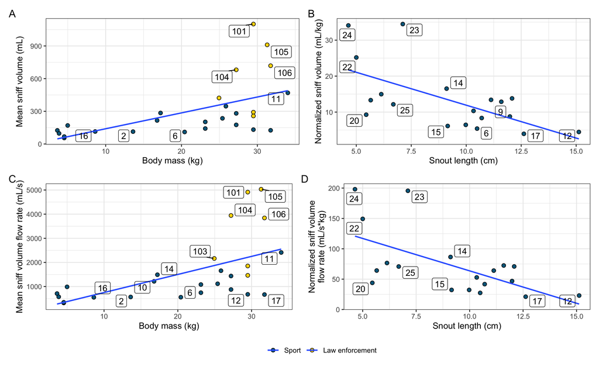

Accompanying statistical analyses:

```
[1] "Regression Fig 5A: sport only"

Call:
lm(formula = sniff_volume ~ weight, data = sniff_summaries_alltrials[sniff_summaries_alltrials$op ==
    "civilian", ])

Residuals:
     Min       1Q   Median       3Q      Max
-137.643  -53.320   -9.069   43.372  192.542

Coefficients:
            Estimate Std. Error t value Pr(>|t|)
(Intercept)   73.862     40.386   1.829   0.0850 .
weight         5.970      1.939   3.080   0.0068 **
---
Signif. codes:  0 ‘***’ 0.001 ‘**’ 0.01 ‘*’ 0.05 ‘.’ 0.1 ‘ ’ 1

Residual standard error: 86.02 on 17 degrees of freedom
Multiple R-squared:  0.3581,    Adjusted R-squared:  0.3203
F-statistic: 9.484 on 1 and 17 DF,  p-value: 0.006796

[1] "Regression Fig 5A: all dogs"

Call:
lm(formula = sniff_volume ~ weight, data = sniff_summaries_alltrials)

Residuals:
    Min      1Q  Median      3Q     Max
-330.98 -131.10  -21.49   60.42  677.12

Coefficients:
            Estimate Std. Error t value Pr(>|t|)
(Intercept)   -5.814    104.600  -0.056  0.95614
weight        14.570      4.475   3.256  0.00336 **
---
Signif. codes:  0 ‘***’ 0.001 ‘**’ 0.01 ‘*’ 0.05 ‘.’ 0.1 ‘ ’ 1

Residual standard error: 228.7 on 24 degrees of freedom
Multiple R-squared:  0.3063,    Adjusted R-squared:  0.2774
F-statistic:  10.6 on 1 and 24 DF,  p-value: 0.003357

[1] "Regression Fig 5B"

Call:
lm(formula = norm_volume ~ snout_length, data = sniff_summaries_alltrials)

Residuals:
    Min      1Q  Median      3Q     Max
-10.970  -5.560  -0.982   3.712  17.274

Coefficients:
             Estimate Std. Error t value Pr(>|t|)
(Intercept)   30.2109     5.4621   5.531 3.66e-05 ***
snout_length  -1.8291     0.5651  -3.237  0.00485 **
---
Signif. codes:  0 ‘***’ 0.001 ‘**’ 0.01 ‘*’ 0.05 ‘.’ 0.1 ‘ ’ 1

Residual standard error: 7.221 on 17 degrees of freedom
  (7 observations deleted due to missingness)
Multiple R-squared:  0.3813,    Adjusted R-squared:  0.3449
F-statistic: 10.48 on 1 and 17 DF,  p-value: 0.00485
```

# Reproduction of statistical values in text of manuscript

```
[1] "Comparing sniff volumes between operational and civilian dogs for all trials"

    Wilcoxon rank sum exact test

data:  sniff_summaries_alltrials$sniff_volume[sniff_summaries_alltrials$op == "civilian"] and sniff_summaries_alltrials$sniff_volume[sniff_summaries_alltrials$op == "operational"]
W = 7, p-value = 0.0001368
alternative hypothesis: true location shift is not equal to 0

[1] "Comparing sniff volume flow rates between operational and civilian dogs for all trials"

    Wilcoxon rank sum exact test

data:  sniff_summaries_alltrials$sniff_vfr[sniff_summaries_alltrials$op == "civilian"] and sniff_summaries_alltrials$sniff_vfr[sniff_summaries_alltrials$op == "operational"]
W = 5, p-value = 5.777e-05
alternative hypothesis: true location shift is not equal to 0


    Wilcoxon rank sum exact test

data:  sniff_summaries_chemical$sniff_freq[sniff_summaries_chemical$trial == 1 & sniff_summaries_chemical$target == "yes"] and sniff_summaries_chemical$sniff_freq[sniff_summaries_chemical$trial == 3 & sniff_summaries_chemical$target == "yes"]
W = 148, p-value = 5.94e-05
alternative hypothesis: true location shift is not equal to 0
```